# Annotation of mobile genetic elements

Produced with bacannot pipeline

26 November 2020

# KpV3 report of mobile genetic elements (MGEs)

## About

Mobile genetic elements (MGEs) are a type of genetic material that can move around within a genome, or that can be transferred from one species or replicon to another. Newly acquired genes through this mechanism can increase fitness by gaining new or additional functions. On the other hand, MGEs can also decrease fitness by introducing disease-causing alleles or mutations. For instance, prophages are bacteriophages that have been inserted and integrated into the bacterial chromosome or plasmid. It is the latent form of a phage. ICEs (integrative and conjugative elements), on the other hand, are integrative mobile genetic elements that encode a conjugation machinery. They can confer selective advantages and can also encode resistance determinants and virulence factors.

In this context, this pipeline is capable of automatically annotating some mobile genetic elements using public available resources such as:

1. [PHAST](https://phaster.ca) database;
   - PHAST (PHAge Search Tool) is a web server designed to rapidly and accurately identify, annotate and graphically display prophage sequences within bacterial genomes or plasmids.
   - Although it does not have a command line interface it has a protein database of prophage genes that were added to this pipeline and are scanned via `BLASTp`
2. [Phigaro](https://github.com/bobeobibo/phigaro);
   - Phigaro is a standalone command-line application that is able to detect prophage regions taking raw genome and metagenome assemblies as an input.
   - It also produces dynamic annotated “prophage genome maps” and marks possible transposon insertion spots inside prophages.
3. PhiSpy;
   - PhiSpy identifies prophages in Bacterial (and probably Archaeal) genomes. Given an annotated genome it will use several approaches to identify the most likely prophage regions.
4. [ICEberg](https://db-mml.sjtu.edu.cn/ICEberg/) database;
   - ICEberg 2.0 is an updated database of bacterial integrative and conjugative elements.
5. [Plasmidfinder](https://cge.cbs.dtu.dk/services/PlasmidFinder/);
   - Plasmidfinder is a tool for the *in silico* detection of plasmids.
6. [Platon](https://github.com/oschwengers/platon);
   - Platon detects plasmid contigs within bacterial draft genomes from WGS short-read assemblies.
   - Therefore, Platon analyzes the natural distribution biases of certain protein coding genes between chromosomes and plasmids.
7. [IslandPath](https://github.com/brinkmanlab/islandpath).
   - IslandPath-DIMOB is a standalone software to predict genomic islands in bacterial and archaeal genomes based on the presence of dinucleotide biases and mobility genes.

### Prediction thresholds

All the predictions were passed through a user defined threshold for minimum coverage and identity:

- Min. Identity (%): `> 65`
- Min. Coverage (%): `> 65`

> [PHAST](https://phaster.ca) is a protein database scanned via BLASTp; [ICEberg](http://202.120.12.136:7913/ICEberg2/) is a protein and nucleotide database that contains the full-length sequences of known ICEs and also contains the sequences of a multitude of proteins commonly found inside these ICEs. Full-length ICEs are blasted to the genome via BLASTn while the protein sequences are blasted tto the predicted genes via BLASTp; [Plasmidfinder](https://cge.cbs.dtu.dk/services/PlasmidFinder/) is a nucleotide database scanned via BLASTn. The other software have its own metrics.

> The results used to create this report are under the directories called `prophages`, `ICEs` and `Plasmids` in the output folder of the query KpV3.

## Genomic Islands prediction

Genomic Islands (GIs) were predicted with [islandPath](https://github.com/brinkmanlab/islandpath). The predicted genomic islands are integrated into the JBrowse genome viewer so that users can interactively interrogate the results and check the genes found inside these islands. The resulting genome browser are provided in the `jbrowse` directory inside the query main output directory. This genome browser can be opened with the http-server command or the [JBrowse Desktop](https://jbrowse.org/docs/jbrowse_desktop.html) software.

Additionally, these genomic islands were parsed in a very generic manner in order to provide a simple visualization of the annotation in these regions. The plots were rendered with the python package [gff-toolbox](https://github.com/fmalmeida/gff-toolbox/wiki) and are available at the directory: `genomic_islands/plots` in the main query output directory. An example of these plots is shown in Figure 1.

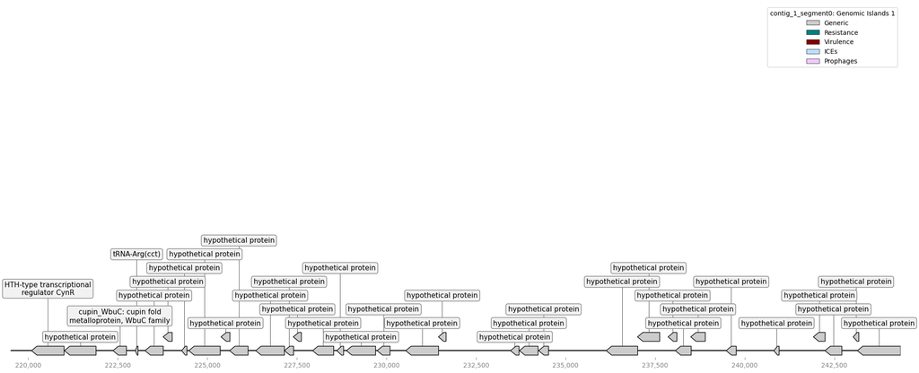

Figure 1: Examplification of the visualization of genomic islands regions with gff-toolbox package.

> As discussed, these images were rendered in a very generic manner just to show some visualization possibilities to the user. If desired, users can check the [gff-toolbox](https://github.com/fmalmeida/gff-toolbox/wiki) package to produce more customized plots.

## Plasmid detection

### Plasmidfinder

[Plasmidfinder](https://cge.cbs.dtu.dk/services/PlasmidFinder/) is a tool for the *in silico* detection of plasmids. Its results are summarized in Table 1

- The complete results can be found in the directory `plasmids/plasmidfinder` under the main output directory.

Table 1: In silico detection of plasmids with Plasmidfinder

| Database | Plasmid Replicon | Identity (%) | Query/Ref Length | Contig | Position in Contig | Notes | Acc. Num. |
| --- | --- | --- | --- | --- | --- | --- | --- |
| enterobacteriaceae | ColRNAI | 100 | 130 / 130 | contig_6_segment0 | 9096..9225 |  | DQ298019 |
| enterobacteriaceae | IncU | 98.94 | 565 / 565 | contig_7_segment0 | 14604..15167 |  | DQ401103 |

### Platon

[Platon](https://github.com/oschwengers/platon) detects plasmid contigs within bacterial draft genomes from WGS short-read assemblies. Therefore, Platon analyzes the natural distribution biases of certain protein coding genes between chromosomes and plasmids. This analysis is complemented by comprehensive contig characterizations upon which several heuristics are applied. Its results are summarized in Table 2.

- The complete results can be found in the directory `plasmids/platon` under the main output directory.

> This software was executed with the paramater `--mode specificity` to decrease the number of false positives.

Table 2: In silico detection of plasmids with Platon

| Contig | Contig Length | Coverage | # ORFs | RDS | Circular | Inc. Type | # Replication | # Mobilization | # OriT | # Conjugation | # AMRs | rRNAs | # Plasmid Hits |
| --- | --- | --- | --- | --- | --- | --- | --- | --- | --- | --- | --- | --- | --- |
| contig_7_segment0 | 17443 |  | 24 | 19.8 | no | 1 | 0 | 0 | 0 | 0 | 1 | 0 | 0 |
| contig_3_segment0 | 16946 |  | 26 | 4.2 | no | 0 | 0 | 0 | 0 | 0 | 0 | 0 | 1 |
| contig_2_segment0 | 11849 |  | 11 | 1.7 | no | 0 | 2 | 0 | 0 | 0 | 0 | 0 | 0 |
| contig_6_segment0 | 9293 |  | 16 | 12.5 | no | 1 | 0 | 0 | 0 | 0 | 0 | 0 | 1 |
| contig_4_segment0 | 2509 |  | 0 | 0 | yes | 0 | 0 | 0 | 0 | 0 | 0 | 0 | 0 |

## Prophage detection

> All the prophage sequences and genes are available in the genome browser proveided, it is worthy taking notes of prophage’s genomic regions for a better exploration using it. The genome browser was automatically created (stored in a dir called `jbrowse`) and can be visualized with [JBROWSE desktop](https://github.com/GMOD/jbrowse) ot http-server.

### Phigaro

Phigaro is a standalone command-line application that is able to detect prophage regions taking raw genome and metagenome assemblies as an input. It also produces dynamic annotated “prophage genome maps” and marks possible transposon insertion spots inside prophages. Its results can be nicely visualized in its own html report file. The genomic regions predicted as putative prophage sequences are also summarized in Table 3.

- Check it out at:
  - Dir: `prophages/phigaro` in the main output directory
  - HTML: `/Volumes/falmeida1TB/bacannot_teste/output/KpV3/prophages/phigaro/KpV3_phigaro.html`

Table 3: Putative prophage sequences annotated with phigaro software

| scaffold | begin | end | transposable | taxonomy | vog |
| --- | --- | --- | --- | --- | --- |
| contig_1_segment0 | 229742 | 257256 | False | Siphoviridae | VOG7624, VOG10933, VOG4829, VOG4548, VOG5751, VOG0296, VOG3445, VOG2123, VOG2123, VOG2096, VOG2388, VOG2125, VOG4547, VOG4771, VOG0051, VOG0051, VOG0051, VOG4361, VOG0833, VOG0833, VOG4672, VOG4672, V… |
| contig_1_segment0 | 1862811 | 1902078 | False | Siphoviridae | VOG5260, VOG9306, VOG9306, VOG9306, VOG9306, VOG9306, VOG9306, VOG9306, VOG4598, VOG4701, VOG0850, VOG0850, VOG0848, VOG0848, VOG4729, VOG4634, VOG4589, VOG0204, VOG9750, VOG4553, VOG4553, VOG4553, VO… |
| contig_1_segment0 | 2650107 | 2690709 | False | Myoviridae | VOG5532, VOG0083, VOG0573, VOG1348, VOG5532, VOG1348, VOG1956, VOG4860, VOG3899, VOG4552, VOG2127, VOG1352, VOG1352, VOG2128, VOG2129, VOG1353, VOG3898, VOG1917, VOG2130, VOG1915, VOG4564, VOG1912, VO… |
| contig_1_segment0 | 4694922 | 4734353 | False | Myoviridae | VOG0275, VOG2215, VOG2186, VOG2187, VOG0584, VOG0585, VOG0586, VOG4732, VOG0588, VOG0588, VOG0979, VOG9847, VOG4567, VOG1931, VOG4556, VOG4556, VOG3897, VOG0566, VOG0566, VOG0764, VOG0567, VOG0568, VO… |
| contig_5_segment0 | 1396 | 23686 | False | Siphoviridae | VOG4720, VOG10340, VOG4891, VOG4581, VOG4556, VOG4573, VOG4573, VOG4553, VOG4553, VOG9750, VOG0204, VOG4589, VOG0539, VOG4634, VOG4729, VOG0847, VOG0848, VOG0850, VOG0850, VOG8428, VOG4701, VOG9306, V… |

### PhiSpy

PhiSpy is a standalone tool that identifies prophages in Bacterial (and probably Archaeal) genomes. Given an annotated genome it will use several approaches to identify the most likely prophage regions.. The genomic regions predicted as putative prophage sequences are also summarized in Table 4.

- Check the results at `prophages/phispy` in the main output directory

Table 4: Putative prophage sequences annotated with phispy software

| Prophage | Contig | Start | End |
| --- | --- | --- | --- |
| pp_1 | contig_1_segment0 | 72559 | 103973 |
| pp_2 | contig_1_segment0 | 237009 | 253589 |
| pp_3 | contig_1_segment0 | 1865766 | 1891240 |
| pp_4 | contig_1_segment0 | 2653795 | 2692820 |
| pp_5 | contig_1_segment0 | 4692874 | 4728136 |
| pp_6 | contig_1_segment0 | 4954080 | 4975277 |
| pp_7 | contig_1_segment0 | 4992172 | 5007337 |
| pp_8 | contig_5_segment0 | 159 | 22584 |

### PHAST database

All prophage genes from PHAST database that had good alignments to the genes of the query genome are summarized in Table 5. The protein sequences of these genes were aligned against the gene sequences predicted by Prokka via BLASTp. They are all available in the genome browser provided. A good way to interrogate this annotation is to visualize the putative prophage regions predicted by phigaro and phispy interpolating it with the prophage gene annotation provided with phast database.

> Unfortunately, PHASTER database have no searchable interface to visualize its prophages. Therefore, this table has no links to external sources.

Table 5: Prophage genes annotated using PHAST database via BLASTp

| Prophage of origin | Description | Query protein | Product | Genomic Position |
| --- | --- | --- | --- | --- |
| PHAGE_Cronob_CR5_NC_021531 | PHAGE_Cronob_CR5_NC_021531-gi\|514051401\|ref\|YP_008125829.1\| PhoH family protein [Cronobacter phage CR5] | BNHFPCLP_02569 | PhoH family protein | contig_1_segment0:2015711-2016499 |
| PHAGE_Cronob_ENT39118_NC_019934 | PHAGE_Cronob_ENT39118_NC_019934-gi\|431811063\|ref\|YP_007238140.1\| endolysin [Cronobacter phage ENT39118] | BNHFPCLP_00318 | endolysin | contig_1_segment0:239764-240393 |
| PHAGE_Entero_186_NC_001317 | PHAGE_Entero_186_NC_001317-gi\|9634085\|ref\|NP_052278.1\| Int [Enterobacteria phage 186] | BNHFPCLP_06100 | Int | contig_1_segment0:4694922-4695938 |
| PHAGE_Entero_186_NC_001317 | PHAGE_Entero_186_NC_001317-gi\|9634086\|ref\|NP_052279.1\| CI repressor [Enterobacteria phage 186] | BNHFPCLP_06101 | CI repressor | contig_1_segment0:4695938-4696609 |
| PHAGE_Entero_186_NC_001317 | PHAGE_Entero_186_NC_001317-gi\|9634089\|ref\|NP_052282.1\| Fil [Enterobacteria phage 186] | BNHFPCLP_06103 | Fil | contig_1_segment0:4697459-4697626 |
| PHAGE_Entero_186_NC_001317 | PHAGE_Entero_186_NC_001317-gi\|9634094\|ref\|NP_052287.1\| Orf83 [Enterobacteria phage 186] | BNHFPCLP_06108 | Orf83 | contig_1_segment0:4698871-4699143 |
| PHAGE_Entero_186_NC_001317 | PHAGE_Entero_186_NC_001317-gi\|9634064\|ref\|NP_052257.1\| holin [Enterobacteria phage 186] | BNHFPCLP_06126 | holin | contig_1_segment0:4713855-4714145 |
| PHAGE_Entero_BP_4795_NC_004813 | PHAGE_Entero_BP_4795_NC_004813-gi\|157166064\|ref\|YP_001449316.1\| hypothetical protein [Enterobacteria phage BP-4795] | BNHFPCLP_03388 | hypothetical protein | contig_1_segment0:2653373-2653798 |
| PHAGE_Entero_BP_4795_NC_004813 | PHAGE_Entero_BP_4795_NC_004813-gi\|157166064\|ref\|YP_001449316.1\| hypothetical protein [Enterobacteria phage BP-4795] | BNHFPCLP_06317 | hypothetical protein | contig_1_segment0:4868518-4868943 |
| PHAGE_Entero_cdtI_NC_009514 | PHAGE_Entero_cdtI_NC_009514-gi\|148609424\|ref\|YP_001272555.1\| Repressor [Enterobacteria phage cdtI] | BNHFPCLP_00305 | Repressor | contig_1_segment0:233012-233212 |

[output cut: 136 more lines]

## ICEs detection

### Analysis of full-length ICEs

Full-length ICEs are available at [ICEberg database](https://bioinfo-mml.sjtu.edu.cn/ICEberg/download.html) in nucleotide fastas while the proteins found inside these ICEs are in protein fastas. Since the ICEfinder script has no licenses to be incorporated to the pipeline, we try to search for the full-length ICEs. However, they are very difficult to be completely found in new genomes, thus they are scanned without coverage or identity thresholds. The filtering and selection of these is up to you. We have found a total of 33 alignments in the query genome, check it out in table 6.

Table 6: Alignment of full-length ICEs to the query genome via BLASTn

|  | Contig | Start | End | Strand | Product | Coverage_aln | Gaps | Coverage % | Identity % | Database | Ref. Accession | Description | NA |
| --- | --- | --- | --- | --- | --- | --- | --- | --- | --- | --- | --- | --- | --- |
| 1 | contig_1_segment0 | 4802870 | 4807048 | + | ICE_288 | 122687-126863/133500 | 6/8 | 3.13 | 90.65 | ICEberg | AL513382 | SPI-7 | ICEberg\|288\|SPI-7\|GenBank\|AL513382\|4409574..4543073 Salmonella enterica subsp. enterica serovar Typhi str. CT18, complete chromosome. |
| 2 | contig_1_segment0 | 4800719 | 4802874 | + | ICE_288 | 120399-122560/133500 | 14/16 | 1.61 | 86.8 | ICEberg | AL513382 | SPI-7 | ICEberg\|288\|SPI-7\|GenBank\|AL513382\|4409574..4543073 Salmonella enterica subsp. enterica serovar Typhi str. CT18, complete chromosome. |
| 3 | contig_1_segment0 | 4838442 | 4839209 | + | ICE_288 | 108701-109468/133500 | 0/0 | 0.58 | 96.75 | ICEberg | AL513382 | SPI-7 | ICEberg\|288\|SPI-7\|GenBank\|AL513382\|4409574..4543073 Salmonella enterica subsp. enterica serovar Typhi str. CT18, complete chromosome. |
| 4 | contig_1_segment0 | 5336535 | 5336579 | + | ICE_288 | 64260-64304/133500 | 0/0 | 0.03 | 97.78 | ICEberg | AL513382 | SPI-7 | ICEberg\|288\|SPI-7\|GenBank\|AL513382\|4409574..4543073 Salmonella enterica subsp. enterica serovar Typhi str. CT18, complete chromosome. |
| 5 | contig_1_segment0 | 4698023 | 4698102 | + | ICE_288 | 94547-94627/133500 | 3/3 | 0.06 | 84.15 | ICEberg | AL513382 | SPI-7 | ICEberg\|288\|SPI-7\|GenBank\|AL513382\|4409574..4543073 Salmonella enterica subsp. enterica serovar Typhi str. CT18, complete chromosome. |
| 6 | contig_1_segment0 | 3400336 | 3403466 | + | ICE_406 | 52024-55156/98112 | 34/40 | 3.17 | 77.73 | ICEberg | AJ627388 | YAPI | ICEberg\|406\|YAPI\|GenBank\|AJ627388\|1402..99513 Yersinia pseudotuberculosis adhesion pathogenicity island (YAPI), complete sequence, strain 32777. |
| 7 | contig_1_segment0 | 3397287 | 3399013 | + | ICE_406 | 47798-49522/98112 | 7/8 | 1.76 | 82.78 | ICEberg | AJ627388 | YAPI | ICEberg\|406\|YAPI\|GenBank\|AJ627388\|1402..99513 Yersinia pseudotuberculosis adhesion pathogenicity island (YAPI), complete sequence, strain 32777. |
| 8 | contig_1_segment0 | 3586966 | 3587023 | + | ICE_406 | 98055-98112/98112 | 0/0 | 0.06 | 96.55 | ICEberg | AJ627388 | YAPI | ICEberg\|406\|YAPI\|GenBank\|AJ627388\|1402..99513 Yersinia pseudotuberculosis adhesion pathogenicity island (YAPI), complete sequence, strain 32777. |
| 9 | contig_1_segment0 | 2716966 | 2717005 | + | ICE_406 | 55208-55248/98112 | 1/1 | 0.04 | 95.12 | ICEberg | AJ627388 | YAPI | ICEberg\|406\|YAPI\|GenBank\|AJ627388\|1402..99513 Yersinia pseudotuberculosis adhesion pathogenicity island (YAPI), complete sequence, strain 32777. |
| 10 | contig_1_segment0 | 4243235 | 4243268 | + | ICE_406 | 55215-55248/98112 | 0/0 | 0.03 | 100 | ICEberg | AJ627388 | YAPI | ICEberg\|406\|YAPI\|GenBank\|AJ627388\|1402..99513 Yersinia pseudotuberculosis adhesion pathogenicity island (YAPI), complete sequence, strain 32777. |

[output cut: 23 more lines]

### Analysis of ICE’s proteins

All query genes predicted by Prokka that have a match in ICEberg database are shown in Table 7. It is summarized the ICE id and all its genes that were found in the query genome. All of them are linked to the database for further investigations.

> Take note: The fact that the genome possess some proteins from ICEs does not necessarily means that the ICE is present in the genome. Please, check the number of proteins that the ICE of origin posses in the [ICEberg database list of ICEs](https://bioinfo-mml.sjtu.edu.cn/ICEberg2/browse_result.php?type=alpha&alpha=100), and them infer based one the alignments you see if your genome have or not one ICE in it.

Users are advised to also use the [ICEfinder](https://bioinfo-mml.sjtu.edu.cn/ICEberg2/tools.html) tool to predict the putative genomic position of known ICEs since we are not allowed to include this step under this pipeline.

Table 7: ICE genes annotated from ICEberg database via BLASTp

|  | Query Protein | ICEberg of origin | Ref. Accession | Product / Gene | Description | Genomic Position | NA |
| --- | --- | --- | --- | --- | --- | --- | --- |
| 1 | BNHFPCLP_01172 | 46 | CAD61138.1 | acetaldehyde dehydrogenase oxidoreductase Cupriavidus oxalaticus | ICEberg\|46 gi\|27817711\|emb\|CAD61138.1\| acetaldehyde dehydrogenase oxidoreductase [Cupriavidus oxalaticus] | contig_1_segment0:933358-934209 | acetaldehyde dehydrogenase oxidoreductase [Cupriavidus oxalaticus] |
| 2 | BNHFPCLP_01174 | 46 | CAD61139.1 | putative 4-hydroxy-2-oxovalerate aldolase transmembrane protein Cupriavidus oxalaticus | ICEberg\|46 gi\|27817712\|emb\|CAD61139.1\| putative 4-hydroxy-2-oxovalerate aldolase transmembrane protein [Cupriavidus oxalaticus] | contig_1_segment0:934435-935223 | putative 4-hydroxy-2-oxovalerate aldolase transmembrane protein [Cupriavidus oxalaticus] |
| 3 | BNHFPCLP_01393 | 1010 | ATB17841.1 | S-(hydroxymethyl)glutathione dehydrogenase/class III alcohol dehydrogenase Pseudomonas aeruginosa | ICEberg\|1010 gi\|1224956919\|ref\|ATB17841.1\| S-(hydroxymethyl)glutathione dehydrogenase/class III alcohol dehydrogenase [Pseudomonas aeruginosa] | contig_1_segment0:1094990-1096108 | S-(hydroxymethyl)glutathione dehydrogenase/class III alcohol dehydrogenase [Pseudomonas aeruginosa] |
| 4 | BNHFPCLP_01829 | 60 | CAF29065.1 | beta-lactamase TEM precursor Haemophilus influenzae | ICEberg\|60 gi\|51507314\|emb\|CAF29065.1\| beta-lactamase TEM precursor [Haemophilus influenzae] | contig_1_segment0:1446666-1447337 | beta-lactamase TEM precursor [Haemophilus influenzae] |
| 5 | BNHFPCLP_02143 | 1077 | AKU09968.1 | thiol peroxidase Azoarcus sp. CIB | ICEberg\|1077 gi\|7674474488\|ref\|AKU09968.1\| thiol peroxidase [Azoarcus sp. CIB] | contig_1_segment0:1696685-1697191 | thiol peroxidase [Azoarcus sp. CIB] |
| 6 | BNHFPCLP_02871 | 75 | CAD31488.1 | PROBABLE TRANSKETOLASE BETA SUBUNIT PROTEIN Mesorhizobium loti R7A | ICEberg\|75 gi\|20803910\|emb\|CAD31488.1\| PROBABLE TRANSKETOLASE BETA SUBUNIT PROTEIN [Mesorhizobium loti R7A] | contig_1_segment0:2262670-2263413 | PROBABLE TRANSKETOLASE BETA SUBUNIT PROTEIN [Mesorhizobium loti R7A] |
| 7 | BNHFPCLP_02872 | 75 | CAD31487.1 | PROBABLE TRANSKETOLASE ALPHA SUBUNIT PROTEIN Mesorhizobium loti R7A | ICEberg\|75 gi\|20803909\|emb\|CAD31487.1\| PROBABLE TRANSKETOLASE ALPHA SUBUNIT PROTEIN [Mesorhizobium loti R7A] | contig_1_segment0:2263661-2264506 | PROBABLE TRANSKETOLASE ALPHA SUBUNIT PROTEIN [Mesorhizobium loti R7A] |
| 8 | BNHFPCLP_03321 | 66 | CAX68159.1 | fructokinase Salmonella enterica subsp. enterica | ICEberg\|66 gi\|327413130\|emb\|CAX68159.1\| fructokinase [Salmonella enterica subsp. enterica] | contig_1_segment0:2598966-2599889 | fructokinase [Salmonella enterica subsp. enterica] |
| 9 | BNHFPCLP_03325 | 66 | CAX68161.1 | sucrose transporter Salmonella enterica subsp. enterica | ICEberg\|66 gi\|327413132\|emb\|CAX68161.1\| sucrose transporter [Salmonella enterica subsp. enterica] | contig_1_segment0:2601678-2603048 | sucrose transporter [Salmonella enterica subsp. enterica] |
| 10 | BNHFPCLP_03383 | 66 | CAX68176.1 | putative insertion sequence protein Salmonella enterica subsp. enterica | ICEberg\|66 gi\|327413146\|emb\|CAX68176.1\| putative insertion sequence protein [Salmonella enterica subsp. enterica] | contig_1_segment0:2650507-2650854 | putative insertion sequence protein [Salmonella enterica subsp. enterica] |

[output cut: 28 more lines]

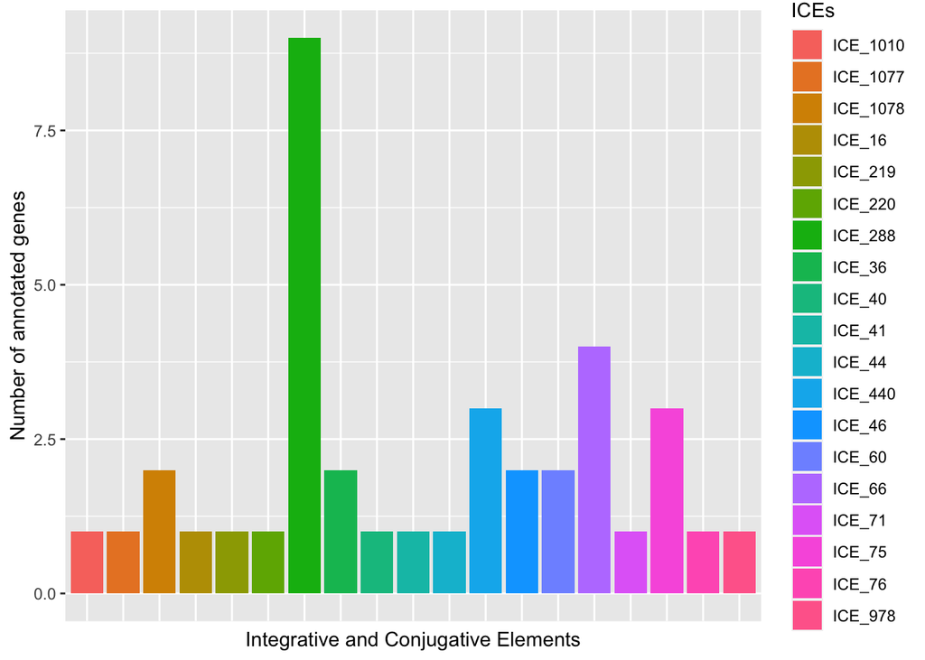

Figure 2: The number of genes from known ICEs (from [ICEberg](https://bioinfo-mml.sjtu.edu.cn/ICEberg2/index.php)) found in the query genome